# PFAS Data Review (SLC Airport Event [190912]

Version 02

T.Hooker

30 September, 2019

## Project Notes

Testing / build area for reviewing PFAS results, including QA sample evaluation

Goal: Look at results from first sampling of SLC-airport PFAS release w/ context of QC samples

[191001] :: New version, re-organizing review and cleaning data upfront

### Current Work

1. Import data
2. Evaluate results
3. Summarize results

## 1.0 Data Import and Cleanup

```r
# file.01  <- choose.files(caption="Select _working_ DATA file [*.CSV]", multi = FALSE)
data01 <- read.csv(file.01, skip = 0,
                   check.names = T,
                   stringsAsFactors = F)
```

**Initial Cleanup Tasks**

- Convert blanks to NAs
- Re-code sample IDs for explicit naming in few variables
- Find and flag dupes
- Clean Result values to numeric and flag non-detects (separately)
- Clarify data.types (concentrations vs. %recovery for surrogates…)
- Keep summary tables terse

```r
data01 %<>% mutate(
  Footnotes = case_when(
    Footnotes == as.character("") ~ as.character(NA),
    TRUE ~ Footnotes))
```

### 1.1 Data Element Review [metadata]

```r
data.file <- data01
#
Data.Vars <- data.frame()
for (i in 1:length(names(data.file))) {
  class_i <- class(data.file[,i])
  name_i <- names(data.file[i])
  num.NAs <- sum(is.na(data.file[,i]))
  count_levels <- as.numeric(length(unique((data.file[,i]))))
  num.blanks <- length(data.file[as.character(data.file[,i]) == "",c(i)]) # fixed for dates
  num.Obs <- nrow(data.file)-num.blanks
Data.Vars <- rbind(Data.Vars, data.frame(i, name_i, class_i, num.NAs, count_levels, num.blanks, num.Obs)) }
#
##
htmlTable::htmlTable(Data.Vars, caption ="Structure of AWQMS Standard-Export-File", align = c("clc|c"), css.cell = rbind(rep("padding-left: 0.7em; padding-right: 0.7em;font-size: 0.8em;", times=ncol(Data.Vars)), matrix("padding-left: 0.7em; padding-right: 0.7em; font-size: 0.8em;",ncol=ncol(Data.Vars), nrow=nrow(Data.Vars))), rnames = FALSE, header = c("Field No.", "Field Name", "Class","NAs", "Levels", "Blanks", "Obs"))
```

| Structure of AWQMS Standard-Export-File Field No. | Structure of AWQMS Standard-Export-File Field Name | Structure of AWQMS Standard-Export-File Class | Structure of AWQMS Standard-Export-File NAs | Structure of AWQMS Standard-Export-File Levels | Structure of AWQMS Standard-Export-File Blanks | Structure of AWQMS Standard-Export-File Obs |
| --- | --- | --- | --- | --- | --- | --- |
| 1 | LabName | character | 0 | 1 | 0 | 837 |
| 2 | LotID | character | 0 | 1 | 0 | 837 |
| 3 | SampleNumber | integer | 471 | 8 | 471 | 366 |
| 4 | Aliquot | character | 0 | 4 | 0 | 837 |
| 5 | Client.ID | character | 0 | 16 | 0 | 837 |
| 6 | Collected | character | 0 | 2 | 0 | 837 |
| 7 | Received | character | 0 | 2 | 0 | 837 |
| 8 | Prepped | character | 0 | 1 | 0 | 837 |
| 9 | Analyzed | character | 0 | 4 | 0 | 837 |
| 10 | Method | character | 0 | 1 | 0 | 837 |
| 11 | Component | character | 0 | 53 | 0 | 837 |
| 12 | CAS | character | 0 | 52 | 0 | 837 |
| 13 | Matrix | character | 0 | 1 | 0 | 837 |
| 14 | Result | character | 0 | 232 | 0 | 837 |
| 15 | Spiked | numeric | 643 | 15 | 643 | 194 |
| 16 | Footnotes | character | 789 | 5 | 789 | 48 |
| 17 | Units | character | 0 | 2 | 0 | 837 |
| 18 | RL | numeric | 322 | 15 | 322 | 515 |
| 19 | MDL | numeric | 322 | 75 | 322 | 515 |
| 20 | QCLot | character | 0 | 6 | 0 | 837 |
| 21 | QCRun | character | 0 | 6 | 0 | 837 |
| 22 | Dilution | integer | 0 | 2 | 0 | 837 |
| 23 | X.Water | integer | 0 | 1 | 0 | 837 |

- Variables where “*Blanks*” are distinct from `NA`s ::
  - All fields are okay
- Check unique levels of `Components` [analyte name] vs. `CAS`

```r
# unique(paste(data01$Component, data01$CAS, sep="_"))
data01 %>% distinct(Component, CAS) %>% arrange(CAS) %>%
  group_by(CAS, Component) %>%
  mutate(Note = as.character(NA)) %>%
  mutate(Note = if_else(CAS %in% .$CAS[duplicated(.$CAS)], "Dupe CAS", as.character(NA))) %>%
  ungroup() %>%
  mutate(Note = case_when(
    grepl("^STL", .$CAS) & is.na(Note) ~ "Surrogate",
    !is.na(Note) ~ Note,
    TRUE ~ as.character(NA))) %>% arrange(as.integer(CAS)) %>%
  htmlTable::htmlTable(., css.cell = rbind(rep("padding-left: 0.8em; padding-right: 0.8em;font-size: 0.75em;", times=ncol(.)+1), matrix("padding-left: 0.75em; padding-right: 0.75em; font-size: 0.75em;", ncol=ncol(.)+1, nrow=nrow(.))), align="rlrc", n.tspanner=c(33,20), tspanner=c("",""))
```

```
NAs introduced by coercion
```

|  | Component | CAS | Note |
| --- | --- | --- | --- |
| 1 | Perfluorohexanoic acid (PFHxA) | 307244 |  |
| 2 | Perfluorododecanoic acid (PFDoA) | 307551 |  |
| 3 | Perfluorooctanoic acid (PFOA) | 335671 |  |
| 4 | Perfluorodecanoic acid (PFDA) | 335762 |  |
| 5 | Perfluorodecanesulfonic acid (PFDS) | 335773 |  |
| 6 | Perfluorohexanesulfonic acid (PFHxS) | 355464 |  |
| 7 | Perfluorobutanoic acid (PFBA) | 375224 |  |
| 8 | Perfluorobutanesulfonic acid (PFBS) | 375735 |  |
| 9 | Perfluoroheptanoic acid (PFHpA) | 375859 |  |
| 10 | Perfluoroheptanesulfonic Acid (PFHpS) | 375928 |  |
| 11 | Perfluorononanoic acid (PFNA) | 375951 |  |
| 12 | Perfluorotetradecanoic acid (PFTeA) | 376067 |  |
| 13 | Perfluorooctanesulfonamide (FOSA) | 754916 |  |
| 14 | Perfluorooctanesulfonic acid (PFOS) | 1763231 |  |
| 15 | Perfluoroundecanoic acid (PFUnA) | 2058948 |  |
| 16 | N-methylperfluorooctanesulfonamidoacetic acid (NMeFOSAA) | 2355319 |  |
| 17 | Perfluoropentanoic acid (PFPeA) | 2706903 |  |
| 18 | Perfluoropentanesulfonic acid (PFPeS) | 2706914 |  |
| 19 | N-ethylperfluorooctanesulfonamidoacetic acid (NEtFOSAA) | 2991506 |  |
| 20 | HFPO-DA (GenX) | 13252136 |  |
| 21 | Perfluoro-n-octadecanoic acid (PFODA) | 16517116 | Dupe CAS |
| 22 | Perfluorooctadecanoic acid | 16517116 | Dupe CAS |
| 23 | 6:2 FTS | 27619972 |  |
| 24 | 8:2 FTS | 39108344 |  |
| 25 | Perfluoro-n-hexadecanoic acid (PFHxDA) | 67905195 |  |
| 26 | Perfluorononanesulfonic acid (PFNS) | 68259121 |  |
| 27 | Perfluorotridecanoic acid (PFTriA) | 72629948 |  |
| 28 | Perfluorododecanesulfonic acid (PFDoS) | 79780395 |  |
| 29 | 10:2 FTS | 120226600 |  |
| 30 | F-53B Major | 756426581 |  |
| 31 | 4:2 FTS | 757124724 |  |
| 32 | F-53B Minor | 763051929 |  |
| 33 | DONA | 919005144 |  |
| 34 | 13C4 PFOA | STL00990 | Surrogate |
| 35 | 13C4 PFOS | STL00991 | Surrogate |
| 36 | 13C4 PFBA | STL00992 | Surrogate |
| 37 | 13C2 PFHxA | STL00993 | Surrogate |
| 38 | 18O2 PFHxS | STL00994 | Surrogate |
| 39 | 13C5 PFNA | STL00995 | Surrogate |
| 40 | 13C2 PFDA | STL00996 | Surrogate |
| 41 | 13C2 PFUnA | STL00997 | Surrogate |
| 42 | 13C2 PFDoA | STL00998 | Surrogate |
| 43 | 13C8 FOSA | STL01056 | Surrogate |
| 44 | 13C4 PFHpA | STL01892 | Surrogate |
| 45 | 13C5 PFPeA | STL01893 | Surrogate |
| 46 | 13C2 PFHxDA | STL02115 | Surrogate |
| 47 | 13C2 PFTeDA | STL02116 | Surrogate |
| 48 | d5-NEtFOSAA | STL02117 | Surrogate |
| 49 | d3-NMeFOSAA | STL02118 | Surrogate |
| 50 | 13C3 HFPO-DA | STL02255 | Surrogate |
| 51 | M2-6:2 FTS | STL02279 | Surrogate |
| 52 | M2-8:2 FTS | STL02280 | Surrogate |
| 53 | M2-4:2 FTS | STL02395 | Surrogate |

- **Q**: How many records associated with the duplicated CAS / Component-name ?

```r
# data01 %>% distinct_at(vars(-Component), .keep_all = T) %>% select(Client.ID, Component, CAS, Result)
setdiff(data01,
        data01 %>% distinct_at(vars(-Component), .keep_all = T)) %>%
  select(Client.ID, Component, CAS, Result) %>%
  htmlTable::htmlTable(., css.cell = rbind(rep("padding-left: 0.8em; padding-right: 0.8em;font-size: 0.75em;", times=ncol(.)+1), matrix("padding-left: 0.75em; padding-right: 0.75em; font-size: 0.75em;", ncol=ncol(.)+1, nrow=nrow(.))))
```

|  | Client.ID | Component | CAS | Result |
| --- | --- | --- | --- | --- |
| 1 | LCS 320-323023/2-A | Perfluorooctadecanoic acid | 16517116 | 46.2 |
| 2 | LCSD 320-323023/3-A | Perfluorooctadecanoic acid | 16517116 | 40.4 |
| 3 | MB 320-323023/1-A | Perfluorooctadecanoic acid | 16517116 | ND |

- For the records above where records are duplicated for CAS numbers but distinct for an `Analyte-name` (Component), exclude the outlier name :: `Perfluorooctadecanoic acid`
  - Add field: `record_exclude` (Y or NA)

```r
data01 %<>% mutate(
  record_exclude = if_else(Component == "Perfluorooctadecanoic acid" & CAS == "16517116",
                           "Y", as.character(NA)))
```

> When the isotopically-labeled surrogate compounds are removed, there are 32 analytes in the dataset
- Look for records where the `Result` may differ but `Component` and `CAS` and `aliquot/client.ID` are the same

```r
# data01 %>% distinct(Aliquot, Client.ID, Component, CAS, .keep_all=T)
# records with duplicate keys but different result values...
setdiff(data01,
        data01 %>% distinct(Aliquot, Client.ID, Component, CAS, .keep_all=T)) %>%
  {. ->> dupe_set} %>% select(Aliquot, Client.ID, Component, CAS, Result)
```

| Aliquot | Client.ID | Component | CAS | Result |
| --- | --- | --- | --- | --- |
| SA | OUTFALL# 4 | 13C4 PFOS | STL00991 | 41 |
| SA | OUTFALL# 4 | 13C4 PFOS | STL00991 | 26 |

- Full set of dupe-recs from above
- Sample “OUTFALL# 4” has 3 records for Surrogate 13C-PFOS
  - This occurred because this sample required multiple sets of dilution in order to quantify this analyte

```r
data01 %>% filter(
  paste(.$Aliquot, .$Client.ID, .$Component, .$CAS) %in%
    (paste(dupe_set$Aliquot, dupe_set$Client.ID, dupe_set$Component, dupe_set$CAS))) %>%
  select(Aliquot, Client.ID, Component, CAS, Result, Units, QCLot) %>% arrange(QCLot)
```

| Aliquot | Client.ID | Component | CAS | Result | Units | QCLot |
| --- | --- | --- | --- | --- | --- | --- |
| SA | OUTFALL# 4 | 13C4 PFOS | STL00991 | 26 | %REC | 320-323190 |
| SA | OUTFALL# 4 | 13C4 PFOS | STL00991 | 41 | %REC | 320-324537 |
| SA | OUTFALL# 4 | 13C4 PFOS | STL00991 | 91 | %REC | 320-324897 |

- Only the last record (QCLot == “320-324897”) is correct; the other records represent analysis from insufficiently diluted sample with very high PFOS (nat. abund.) concentration
  - **Exclude the prior two records**

```r
data01 %<>% mutate(
  record_exclude =case_when(
    paste(.$Aliquot, .$Client.ID, .$Component, .$CAS) %in%
      (paste(dupe_set$Aliquot, dupe_set$Client.ID,
             dupe_set$Component, dupe_set$CAS)) &
      QCLot != "320-324897" ~ "Y",
    !is.na(record_exclude) ~ record_exclude,
    TRUE ~ as.character(NA)))
# Summarize excluded records
data01 %>% filter(!is.na(record_exclude)) %>%
  {addmargins(table(paste(.$Aliquot, .$Client.ID, .$Component, .$CAS),
                       .$record_exclude,
                       useNA="ifany", deparse.level=2))}
```

```
                                                              .$record_exclude
paste(.$Aliquot, .$Client.ID, .$Component, .$CAS)              Y Sum
  LCS LCS 320-323023/2-A Perfluorooctadecanoic acid 16517116   1   1
  LCSD LCSD 320-323023/3-A Perfluorooctadecanoic acid 16517116 1   1
  MB MB 320-323023/1-A Perfluorooctadecanoic acid 16517116     1   1
  SA OUTFALL# 4 13C4 PFOS STL00991                             2   2
  Sum                                                          5   5
```

**Bottom Line**

- 5 records excluded from dataset due to rejected result
  - 3 records for duplicate Component names
  - 2 records for Surrogate recovery of 1 analyte where the QCLot does not match the analytical result QCLot AND the surrogate recoveries are not in control (see review steps below)

### 1.2 Review Var combinations and “levels”

- Already looked at `Component` and `CAS` (above)
- How many Sample numbers ?

  1, 2, 3, 4, 5, 6, 7, QC
  - `NA` in SampleNumber refers to QC samples
- Aliquots ?

  LCS, LCSD, MB, SA
  - `SA` in Aliquot refers to submitted samples
- Client.ID ?

  |  | ..Client.ID | Freq |
  | --- | --- | --- |
  | 1 | DOWNSTREAM | 52 |
  | 2 | DOWNSTREAM BLANK | 52 |
  | 3 | LCS 320-323022/2-A | 52 |
  | 4 | LCS 320-323023/2-A | 53 |
  | 5 | LCS 320-323329/2-A | 52 |
  | 6 | LCSD 320-323022/3-A | 52 |
  | 7 | LCSD 320-323023/3-A | 53 |
  | 8 | LCSD 320-323329/3-A | 52 |
  | 9 | MB 320-323022/1-A | 52 |
  | 10 | MB 320-323023/1-A | 53 |
  | 11 | MB 320-323329/1-A | 52 |
  | 12 | OUTFALL# 4 | 54 |
  | 13 | OUTFALL# 4 BLANK | 52 |
  | 14 | TRIP BLANK | 52 |
  | 15 | UPSTREAM | 52 |
  | 16 | UPSTREAM BLANK | 52 |

  - Can see evidence for some additional records for an LCS, LCSD, and MB QC-samples, as well as additional reported results from OUTFALL #4
- Method ?

  PFC_IDA
- Spiked ?
  - Spike levels (ng/L) can vary depending on exact sample volume in bottle
- Footnotes ?

  |  | ..Footnotes | Freq |
  | --- | --- | --- |
  | 1 | B | 6 |
  | 2 | J | 34 |
  | 3 | J B | 7 |
  | 4 | J I | 1 |
  | 5 |  | 789 |

**B** :: Compound found in Blank and Sample

**J** :: Result was between MDL and RL, thus the Result-value is approximate [*estimated*]

**I** :: Value is `EMPC` (estimated maximum possible concentration);  
*“The transition mass-ratio for the analyte was outside the established ratio limits”*.  
*`Thus, there may be some uncertainty in analyte identification`*

*NA* :: These records may have reportable results, **OR** result have been *Not Detected* with **ND** shown in the result column

- Units ?

  |  | ..Units | Freq |
  | --- | --- | --- |
  | 1 | %REC | 322 |
  | 2 | ng/L | 515 |

**%REC** :: Recovery of isotopically labeled surrogate compounds

### Simplify data-types, result-values, and sample-name classes

**Samp_ID** :: combination of Aliquot (for QC samples) and Client.ID (for field samples) that provide unique identifiers for all “sample” types

- Also, **re-code** SampleNumber, so that Lab-QC samples (where SampleNumber is NA) are explicitly labeled

```r
data01 %<>% mutate(
  Samp_ID = if_else(Aliquot == "SA", Client.ID, Aliquot),
  SampleNumber = ifelse(is.na(SampleNumber), "QC", SampleNumber)) %>%
  select(-LabName, -LotID, -Received, -Prepped, -Analyzed, -Method,
         -Matrix, -QCRun, -Dilution, -X.Water, everything()) %>%
  select(record_exclude, Samp_ID, everything())
```

- Extract QC-batch info from Client.ID of QC samples, as `Samp_grp`
- Add `Samp_type` to ID field-samples vs. *any* blanks or QC

```r
data01 %<>% mutate(Samp_grp = sub(".*- *(.*?) */.*", "\\1", Client.ID)) %>%
  mutate(
    Samp_type = case_when(
      Aliquot == "SA" & !grepl("BLANK", .$Client.ID) ~ "f_samp",
      Aliquot == "SA" & grepl("BLANK", .$Client.ID) ~ "f_qc",
      Aliquot != "SA" ~ "lab_qc")) %>%
  select(record_exclude, Samp_type, Samp_grp, everything())
```

### 1.3 Organize data-records for visual review

```r
data01 %<>% arrange(CAS, SampleNumber, Aliquot, Client.ID, LotID)
```

- **Add `VALUE` as data-type** [*based on “Units”*]

```r
data01 %<>% mutate(VALUE = as.character(NA)) %>% mutate(
  VALUE = case_when(
    Units == "%REC" ~ "Recovery",
    Units == "ng/L" ~ "Conc",
    TRUE ~ as.character(NA))) %>%
  select(record_exclude:Footnotes, VALUE, everything())
```

### 1.4 Convert results to numeric and add ND dataflags

```r
data01 %<>% mutate(
  Result.Value = as.numeric(Result),
  Result_flag = case_when(
    Result == "ND" ~ "U",
    TRUE ~ as.character(NA))) %>%
  select(record_exclude:Result,
         Result.Value, Spiked, Result_flag, everything())
```

```
NAs introduced by coercion
```

```r
data01 %>% filter(is.na(record_exclude)) %>%
  {addmargins(table(.$Footnotes, .$Result_flag, useNA="ifany", deparse.level = 2))}
```

```
           .$Result_flag
.$Footnotes   U <NA> Sum
       B      0    6   6
       J      0   34  34
       J B    0    7   7
       J I    0    1   1
       <NA> 237  547 784
       Sum  237  595 832
```

## 2.0 Data Review

### Review Criteria and Actions

1. **Method Blanks** :: *Lab Reagent Blank*
- MB should be below detection **OR** < 1/3 of MRL (*for target analytes*)
- If MB $\geq$ MRL, then Field Blank needed
- For any Blank (including MB (or LRB)), if RV > MDL (*i.e. detected*), but analyte is NOT Detected in the accompanying sample, the Non-Detects do not need to be qualified
2. **Lab Control Sample** [LCS] & **Duplicates** [LCSD] :: *Lab Fortified Blank*
- % Recovery :: > 70% AND $\leq$ 130% ($\pm$ 30%) (*for both LCS and LCSD*)
- % Relative Percent Difference (%RPD) :: < 30%
3. **Surrogate** recovery
- A test for matrix effects *or* efficiency of analytical method
- Recovery $\pm$ 30%
- Should include Blanks here (MD)
4. Review **Sample-Blanks** :: *Field Blanks* or *Trip Blank*
5. Compare results across field-samples

### 2.1 Method Blanks

- Initially, for single sample-submission-sets, compare all MBs by Analyte
  - Ignore Surrogate compounds here

```r
data01 %>% filter(Aliquot == "MB") %>% filter(!grepl("^STL", .$CAS)) %>%
  {addmargins(table(.$Component, is.na(.$Result.Value),
                    useNA = "ifany", deparse.level = 2,
                    dnn=c("Analyte", "Result Not detected")),1)} %>%
  as.data.frame(stringsAsFactors=F) %>%
  spread(Result.Not.detected, Freq) %>%
  setNames(., c("Analyte", "Detected", "Not Detected")) %>%
  filter(Detected > as.double(0)) %>%
  htmlTable::htmlTable(., css.cell = rbind(rep("padding-left: 0.8em; padding-right: 0.8em;font-size: 0.75em;", times=ncol(.)+1), matrix("padding-left: 0.75em; padding-right: 0.75em; font-size: 0.75em;", ncol=ncol(.)+1, nrow=nrow(.))), align="rlcc", total=T, caption="Analytes where Method-Blanks had at least 1 detectable result")
```

| Analytes where Method-Blanks had at least 1 detectable result | Analytes where Method-Blanks had at least 1 detectable result Analyte | Analytes where Method-Blanks had at least 1 detectable result Detected | Analytes where Method-Blanks had at least 1 detectable result Not Detected |
| --- | --- | --- | --- |
| 1 | Perfluorohexanesulfonic acid (PFHxS) | 3 | 0 |
| 2 | Perfluorooctanesulfonamide (FOSA) | 2 | 1 |
| 3 | Perfluorooctanesulfonic acid (PFOS) | 1 | 2 |
| 4 | Perfluorotetradecanoic acid (PFTeA) | 1 | 2 |
| 5 | Sum | 7 | 90 |

```r
# data01 -> data01_copy
# data01 <- data01_copy
```

- Analytes where at least 1 Method-Blank had a detectable result
  - For MBs w/ a detection, were Result.Values $\gt \frac{1}{3}$ of MRL ?

```r
data01 %>% filter(Aliquot == "MB" & !grepl("^STL", .$CAS)) %>% filter(!is.na(Result.Value)) %>%
  select(Client.ID, Component, Result.Value, RL, Units) %>%
  mutate(Blank_flag = if_else(Result.Value > (RL/3), "B", as.character(NA))) %>%
  arrange(Component) %>%
   htmlTable::htmlTable(., css.cell = rbind(rep("padding-left: 0.8em; padding-right: 0.8em;font-size: 0.75em;", times=ncol(.)+1), matrix("padding-left: 0.75em; padding-right: 0.75em; font-size: 0.75em;", ncol=ncol(.)+1, nrow=nrow(.))), align="llrrlc", n.tspanner=c(3,2,1,1), tspanner=rep("",4), caption="Record IDs where an analyte was detected in Method Blanks", tfoot="Blank flag (B) identifies records where analyte in MB was detected AND result was > 1/3 of MRL")
```

| Record IDs where an analyte was detected in Method Blanks | Record IDs where an analyte was detected in Method Blanks Client.ID | Record IDs where an analyte was detected in Method Blanks Component | Record IDs where an analyte was detected in Method Blanks Result.Value | Record IDs where an analyte was detected in Method Blanks RL | Record IDs where an analyte was detected in Method Blanks Units | Record IDs where an analyte was detected in Method Blanks Blank_flag |
| --- | --- | --- | --- | --- | --- | --- |
| 1 | MB 320-323022/1-A | Perfluorohexanesulfonic acid (PFHxS) | 0.327 | 2 | ng/L |  |
| 2 | MB 320-323023/1-A | Perfluorohexanesulfonic acid (PFHxS) | 0.244 | 2 | ng/L |  |
| 3 | MB 320-323329/1-A | Perfluorohexanesulfonic acid (PFHxS) | 0.442 | 2 | ng/L |  |
| 4 | MB 320-323023/1-A | Perfluorooctanesulfonamide (FOSA) | 0.382 | 2 | ng/L |  |
| 5 | MB 320-323329/1-A | Perfluorooctanesulfonamide (FOSA) | 0.484 | 2 | ng/L |  |
| 6 | MB 320-323022/1-A | Perfluorooctanesulfonic acid (PFOS) | 0.852 | 2 | ng/L | B |
| 7 | MB 320-323329/1-A | Perfluorotetradecanoic acid (PFTeA) | 0.312 | 2 | ng/L |  |

Blank flag (B) identifies records where analyte in MB was detected AND result was > 1/3 of MRL

**Sample QCLot associated with the B-flagged MB (for PFOS)** ::

- 320-323197

```r
data01 %<>% mutate(
  Blank_flag = case_when(
    Aliquot == "MB" &
      !grepl("^STL", .$CAS) &
      !is.na(Result.Value) & Result.Value > (RL/3) ~ "B",
    TRUE ~ as.character(NA))) %>%
  select(record_exclude:Footnotes, Blank_flag, everything())
```

- The following sample-records have a B-flag associated with this hit on the MB-PFOS

```r
data01 %>% filter(is.na(record_exclude)) %>% filter(QCLot %in% (data01 %>% filter(Aliquot == "MB" & !grepl("^STL", .$CAS)) %>% filter(!is.na(Result.Value)) %>% mutate(Blank_flag = if_else(Result.Value > (RL/3), "B", as.character(NA))) %>% filter(!is.na(Blank_flag)) %>% select(QCLot) %$% QCLot)) %>% filter(CAS == "1763231") %>% select(Samp_grp, Samp_ID, Component, Result.Value, Result_flag, Footnotes, RL, MDL, Units) %>% htmlTable::htmlTable(., css.cell = rbind(rep("padding-left: 0.8em; padding-right: 0.8em;font-size: 0.75em;", times=ncol(.)+1), matrix("padding-left: 0.75em; padding-right: 0.75em; font-size: 0.75em;", ncol=ncol(.)+1, nrow=nrow(.))), align="rlll|rrc|rr|c", caption="Records associated with the MB-PFOS detection")
```

| Records associated with the MB-PFOS detection | Records associated with the MB-PFOS detection Samp_grp | Records associated with the MB-PFOS detection Samp_ID | Records associated with the MB-PFOS detection Component | Records associated with the MB-PFOS detection Result.Value | Records associated with the MB-PFOS detection Result_flag | Records associated with the MB-PFOS detection Footnotes | Records associated with the MB-PFOS detection RL | Records associated with the MB-PFOS detection MDL | Records associated with the MB-PFOS detection Units |
| --- | --- | --- | --- | --- | --- | --- | --- | --- | --- |
| 1 | UPSTREAM | UPSTREAM | Perfluorooctanesulfonic acid (PFOS) | 19 |  | B | 1.9 | 0.5 | ng/L |
| 2 | DOWNSTREAM | DOWNSTREAM | Perfluorooctanesulfonic acid (PFOS) | 59 |  | B | 1.7 | 0.47 | ng/L |
| 3 | TRIP BLANK | TRIP BLANK | Perfluorooctanesulfonic acid (PFOS) | 1.2 |  | J B | 1.8 | 0.5 | ng/L |
| 4 | 323022 | LCS | Perfluorooctanesulfonic acid (PFOS) | 39.4 |  |  | 2 | 0.54 | ng/L |
| 5 | 323022 | LCSD | Perfluorooctanesulfonic acid (PFOS) | 37.3 |  |  | 2 | 0.54 | ng/L |
| 6 | 323022 | MB | Perfluorooctanesulfonic acid (PFOS) | 0.852 |  | J | 2 | 0.54 | ng/L |

- The above sample records may have a positive bias in PFOS concentrations…
  - Field blanks were collected at each sampling locations, in addition to a Trip Blank, so field-sample results can be reviewed further for evidence of possible bias

### 2.2 Lab Control Samples (*lab spikes*)

- Calculate %Recovery for LCS and LCSD samples for all analytes

```r
data01 %>% filter(is.na(record_exclude)) %>%
  filter(Samp_ID %in% c("LCS", "LCSD")) %>%
  filter(!grepl("^STL", .$CAS)) %>%
  group_by(Component, Samp_ID) %>%
  mutate(Recovery = signif(Result.Value / as.numeric(Spiked), digits=2)*100) %>%
  mutate(Recov_flag = if_else((Recovery > 130), "Bias-high", as.character(NA)),
         Recov_flag = if_else((Recovery < 70), "Bias-lo", as.character(NA))) %>%
  summarise(avg_Recovery = ceiling(mean(Recovery, na.rm = T))) %>%
  spread(Samp_ID, avg_Recovery) %>%
  htmlTable::htmlTable(., css.cell = rbind(rep("padding-left: 0.8em; padding-right: 0.8em;font-size: 0.75em;", times=ncol(.)+1), matrix("padding-left: 0.75em; padding-right: 0.75em; font-size: 0.75em;", ncol=ncol(.)+1, nrow=nrow(.))), align="rl|rr", caption="Average recovery (over three QC-groups) of Lab-Control-Samples and LCS-duplicates (spike ~ 40 ng/L)", tfoot="LCS control limits are &plusmn; 30%")
```

| Average recovery (over three QC-groups) of Lab-Control-Samples and LCS-duplicates (spike ~ 40 ng/L) | Average recovery (over three QC-groups) of Lab-Control-Samples and LCS-duplicates (spike ~ 40 ng/L) Component | Average recovery (over three QC-groups) of Lab-Control-Samples and LCS-duplicates (spike ~ 40 ng/L) LCS | Average recovery (over three QC-groups) of Lab-Control-Samples and LCS-duplicates (spike ~ 40 ng/L) LCSD |
| --- | --- | --- | --- |
| 1 | 10:2 FTS | 94 | 98 |
| 2 | 4:2 FTS | 117 | 111 |
| 3 | 6:2 FTS | 117 | 117 |
| 4 | 8:2 FTS | 107 | 101 |
| 5 | DONA | 111 | 111 |
| 6 | F-53B Major | 111 | 107 |
| 7 | F-53B Minor | 93 | 88 |
| 8 | HFPO-DA (GenX) | 113 | 114 |
| 9 | N-ethylperfluorooctanesulfonamidoacetic acid (NEtFOSAA) | 104 | 111 |
| 10 | N-methylperfluorooctanesulfonamidoacetic acid (NMeFOSAA) | 117 | 110 |
| 11 | Perfluoro-n-hexadecanoic acid (PFHxDA) | 104 | 114 |
| 12 | Perfluoro-n-octadecanoic acid (PFODA) | 114 | 110 |
| 13 | Perfluorobutanesulfonic acid (PFBS) | 106 | 101 |
| 14 | Perfluorobutanoic acid (PFBA) | 107 | 111 |
| 15 | Perfluorodecanesulfonic acid (PFDS) | 100 | 102 |
| 16 | Perfluorodecanoic acid (PFDA) | 107 | 111 |
| 17 | Perfluorododecanesulfonic acid (PFDoS) | 96 | 99 |
| 18 | Perfluorododecanoic acid (PFDoA) | 107 | 103 |
| 19 | Perfluoroheptanesulfonic Acid (PFHpS) | 111 | 104 |
| 20 | Perfluoroheptanoic acid (PFHpA) | 104 | 104 |
| 21 | Perfluorohexanesulfonic acid (PFHxS) | 90 | 92 |
| 22 | Perfluorohexanoic acid (PFHxA) | 100 | 111 |
| 23 | Perfluorononanesulfonic acid (PFNS) | 111 | 107 |
| 24 | Perfluorononanoic acid (PFNA) | 107 | 111 |
| 25 | Perfluorooctanesulfonamide (FOSA) | 100 | 100 |
| 26 | Perfluorooctanesulfonic acid (PFOS) | 106 | 103 |
| 27 | Perfluorooctanoic acid (PFOA) | 96 | 99 |
| 28 | Perfluoropentanesulfonic acid (PFPeS) | 99 | 99 |
| 29 | Perfluoropentanoic acid (PFPeA) | 100 | 100 |
| 30 | Perfluorotetradecanoic acid (PFTeA) | 97 | 103 |
| 31 | Perfluorotridecanoic acid (PFTriA) | 97 | 102 |
| 32 | Perfluoroundecanoic acid (PFUnA) | 96 | 104 |

LCS control limits are ± 30%

- Number of records where %Recovery is outside 100 ± 30% :: No records found

#### **Precision of LCS sets (analytical repeatability)**

```r
data01 %>% filter(is.na(record_exclude)) %>%
  filter(Aliquot %in% c("LCS", "LCSD") & !grepl("^STL", .$CAS)) %>%
  group_by(Component) %>%
  mutate(Recovery = signif(Result.Value / as.numeric(Spiked), digits=2)*100) %>%
  select(Samp_grp, Samp_ID, Component, Recovery) %>%
  group_by(Component, Samp_grp) %>%
  summarize(grp_Recov = round(mean(Recovery, na.rm=T), digits=1)) %>%
  group_by(Component) %>%
  summarize(Avg_Recov = round(mean(grp_Recov, na.rm=T), digits=1),
            sd_recov = round(sd(grp_Recov, na.rm=T), digits = 1)) %>%
  htmlTable::htmlTable(., css.cell = rbind(rep("padding-left: 0.8em; padding-right: 0.8em;font-size: 0.75em;", times=ncol(.)+1), matrix("padding-left: 0.75em; padding-right: 0.75em; font-size: 0.75em;", ncol=ncol(.)+1, nrow=nrow(.))), align="rlcc", header=c("Analyte", "Avg % Recovery", "StdDev"), caption="Aggregate (avg) recovery across LCS and LCSD QC-samples for 3 QC lots")
```

| Aggregate (avg) recovery across LCS and LCSD QC-samples for 3 QC lots | Aggregate (avg) recovery across LCS and LCSD QC-samples for 3 QC lots Analyte | Aggregate (avg) recovery across LCS and LCSD QC-samples for 3 QC lots Avg % Recovery | Aggregate (avg) recovery across LCS and LCSD QC-samples for 3 QC lots StdDev |
| --- | --- | --- | --- |
| 1 | 10:2 FTS | 95.5 | 2.6 |
| 2 | 4:2 FTS | 113.3 | 2.9 |
| 3 | 6:2 FTS | 116.7 | 2.9 |
| 4 | 8:2 FTS | 103.7 | 5.6 |
| 5 | DONA | 110 | 0 |
| 6 | F-53B Major | 108.3 | 5.8 |
| 7 | F-53B Minor | 90 | 5.3 |
| 8 | HFPO-DA (GenX) | 113.2 | 7.9 |
| 9 | N-ethylperfluorooctanesulfonamidoacetic acid (NEtFOSAA) | 106.7 | 2.9 |
| 10 | N-methylperfluorooctanesulfonamidoacetic acid (NMeFOSAA) | 113.3 | 7.6 |
| 11 | Perfluoro-n-hexadecanoic acid (PFHxDA) | 108.3 | 2.9 |
| 12 | Perfluoro-n-octadecanoic acid (PFODA) | 111.7 | 7.6 |
| 13 | Perfluorobutanesulfonic acid (PFBS) | 103 | 10.4 |
| 14 | Perfluorobutanoic acid (PFBA) | 108.3 | 2.9 |
| 15 | Perfluorodecanesulfonic acid (PFDS) | 100.3 | 4.2 |
| 16 | Perfluorodecanoic acid (PFDA) | 108.3 | 2.9 |
| 17 | Perfluorododecanesulfonic acid (PFDoS) | 97.3 | 4.8 |
| 18 | Perfluorododecanoic acid (PFDoA) | 104.5 | 0.9 |
| 19 | Perfluoroheptanesulfonic Acid (PFHpS) | 106.7 | 2.9 |
| 20 | Perfluoroheptanoic acid (PFHpA) | 103.3 | 5.8 |
| 21 | Perfluorohexanesulfonic acid (PFHxS) | 90.5 | 3.1 |
| 22 | Perfluorohexanoic acid (PFHxA) | 105 | 0 |
| 23 | Perfluorononanesulfonic acid (PFNS) | 108.3 | 2.9 |
| 24 | Perfluorononanoic acid (PFNA) | 108.3 | 2.9 |
| 25 | Perfluorooctanesulfonamide (FOSA) | 99.5 | 0.9 |
| 26 | Perfluorooctanesulfonic acid (PFOS) | 104 | 6.6 |
| 27 | Perfluorooctanoic acid (PFOA) | 97 | 0.5 |
| 28 | Perfluoropentanesulfonic acid (PFPeS) | 98.7 | 1.4 |
| 29 | Perfluoropentanoic acid (PFPeA) | 99.3 | 0.6 |
| 30 | Perfluorotetradecanoic acid (PFTeA) | 100 | 0.5 |
| 31 | Perfluorotridecanoic acid (PFTriA) | 99.2 | 2.5 |
| 32 | Perfluoroundecanoic acid (PFUnA) | 99.3 | 2.3 |

- **All Lab Control Samples (spikes) have recovery within control limits**
  - Instrument is functioning sufficiently, and analytes are readily identified and quantified at 40 ng/L (nominal) level

### 2.3 Recovery of Surrogates

- Lab Method-Blanks (MB)

```r
data01 %>% filter(is.na(record_exclude) & grepl("^STL", .$CAS)) %>%
  filter(Samp_ID == "MB") %>%
  group_by(Component) %>%
  summarize(Obs = n(),
            min_Recov = min(Result.Value, na.rm=T),
            max_Recov = max(Result.Value, na.rm=T),
            Poor_Recov = sum(Result.Value > 130 | Result.Value < 70)) %>%
  htmlTable::htmlTable(., css.cell = rbind(rep("padding-left: 0.8em; padding-right: 0.8em;font-size: 0.75em;", times=ncol(.)+1), matrix("padding-left: 0.75em; padding-right: 0.75em; font-size: 0.75em;", ncol=ncol(.)+1, nrow=nrow(.))), align="rl|cccc", caption="Surrogate recovery for Method-Blank samples")
```

| Surrogate recovery for Method-Blank samples | Surrogate recovery for Method-Blank samples Component | Surrogate recovery for Method-Blank samples Obs | Surrogate recovery for Method-Blank samples min_Recov | Surrogate recovery for Method-Blank samples max_Recov | Surrogate recovery for Method-Blank samples Poor_Recov |
| --- | --- | --- | --- | --- | --- |
| 1 | 13C2 PFDA | 3 | 103 | 107 | 0 |
| 2 | 13C2 PFDoA | 3 | 102 | 107 | 0 |
| 3 | 13C2 PFHxA | 3 | 101 | 103 | 0 |
| 4 | 13C2 PFHxDA | 3 | 82 | 100 | 0 |
| 5 | 13C2 PFTeDA | 3 | 93 | 100 | 0 |
| 6 | 13C2 PFUnA | 3 | 104 | 108 | 0 |
| 7 | 13C3 HFPO-DA | 3 | 104 | 111 | 0 |
| 8 | 13C4 PFBA | 3 | 97 | 103 | 0 |
| 9 | 13C4 PFHpA | 3 | 101 | 106 | 0 |
| 10 | 13C4 PFOA | 3 | 105 | 107 | 0 |
| 11 | 13C4 PFOS | 3 | 98 | 111 | 0 |
| 12 | 13C5 PFNA | 3 | 102 | 109 | 0 |
| 13 | 13C5 PFPeA | 3 | 99 | 106 | 0 |
| 14 | 13C8 FOSA | 3 | 99 | 99 | 0 |
| 15 | 18O2 PFHxS | 3 | 113 | 122 | 0 |
| 16 | d3-NMeFOSAA | 3 | 80 | 99 | 0 |
| 17 | d5-NEtFOSAA | 3 | 80 | 100 | 0 |
| 18 | M2-4:2 FTS | 3 | 91 | 114 | 0 |
| 19 | M2-6:2 FTS | 3 | 91 | 110 | 0 |
| 20 | M2-8:2 FTS | 3 | 95 | 113 | 0 |

> Surrogate recoveries for Method-Blanks are within limits
- Lab Control Samples (LCS)

```r
data01 %>% filter(is.na(record_exclude) & grepl("^STL", .$CAS)) %>%
  filter(grepl("LCS", .$Samp_ID)) %>%
  group_by(Component) %>%
  summarize(Obs = n(),
            min_Recov = min(Result.Value, na.rm=T),
            max_Recov = max(Result.Value, na.rm=T),
            Poor_Recov = sum(Result.Value > 130 | Result.Value < 70)) %>%
  htmlTable::htmlTable(., css.cell = rbind(rep("padding-left: 0.8em; padding-right: 0.8em;font-size: 0.75em;", times=ncol(.)+1), matrix("padding-left: 0.75em; padding-right: 0.75em; font-size: 0.75em;", ncol=ncol(.)+1, nrow=nrow(.))), align="rl|cccc", caption="Surrogate recovery for Lab-Control [spike] samples")
```

| Surrogate recovery for Lab-Control [spike] samples | Surrogate recovery for Lab-Control [spike] samples Component | Surrogate recovery for Lab-Control [spike] samples Obs | Surrogate recovery for Lab-Control [spike] samples min_Recov | Surrogate recovery for Lab-Control [spike] samples max_Recov | Surrogate recovery for Lab-Control [spike] samples Poor_Recov |
| --- | --- | --- | --- | --- | --- |
| 1 | 13C2 PFDA | 6 | 100 | 112 | 0 |
| 2 | 13C2 PFDoA | 6 | 100 | 112 | 0 |
| 3 | 13C2 PFHxA | 6 | 99 | 109 | 0 |
| 4 | 13C2 PFHxDA | 6 | 74 | 108 | 0 |
| 5 | 13C2 PFTeDA | 6 | 92 | 100 | 0 |
| 6 | 13C2 PFUnA | 6 | 105 | 115 | 0 |
| 7 | 13C3 HFPO-DA | 6 | 83 | 108 | 0 |
| 8 | 13C4 PFBA | 6 | 97 | 107 | 0 |
| 9 | 13C4 PFHpA | 6 | 99 | 107 | 0 |
| 10 | 13C4 PFOA | 6 | 105 | 109 | 0 |
| 11 | 13C4 PFOS | 6 | 98 | 116 | 0 |
| 12 | 13C5 PFNA | 6 | 96 | 109 | 0 |
| 13 | 13C5 PFPeA | 6 | 100 | 107 | 0 |
| 14 | 13C8 FOSA | 6 | 97 | 102 | 0 |
| 15 | 18O2 PFHxS | 6 | 111 | 123 | 0 |
| 16 | d3-NMeFOSAA | 6 | 78 | 101 | 0 |
| 17 | d5-NEtFOSAA | 6 | 77 | 100 | 0 |
| 18 | M2-4:2 FTS | 6 | 92 | 108 | 0 |
| 19 | M2-6:2 FTS | 6 | 88 | 109 | 0 |
| 20 | M2-8:2 FTS | 6 | 93 | 120 | 0 |

> Surrogate recoveries for Lab-control-samples are within limits
- Field-Blanks

```r
data01 %>% filter(is.na(record_exclude) & grepl("^STL", .$CAS)) %>%
  filter(grepl("BLANK", .$Samp_ID)) %>%
  group_by(Component) %>%
  summarize(Obs = n(),
            min_Recov = min(Result.Value, na.rm=T),
            max_Recov = max(Result.Value, na.rm=T),
            Poor_Recov = sum(Result.Value > 130 | Result.Value < 70)) %>%
  htmlTable::htmlTable(., css.cell = rbind(rep("padding-left: 0.8em; padding-right: 0.8em;font-size: 0.75em;", times=ncol(.)+1), matrix("padding-left: 0.75em; padding-right: 0.75em; font-size: 0.75em;", ncol=ncol(.)+1, nrow=nrow(.))), align="rl|cccc", caption="Surrogate recovery for Field-Blank samples")
```

| Surrogate recovery for Field-Blank samples | Surrogate recovery for Field-Blank samples Component | Surrogate recovery for Field-Blank samples Obs | Surrogate recovery for Field-Blank samples min_Recov | Surrogate recovery for Field-Blank samples max_Recov | Surrogate recovery for Field-Blank samples Poor_Recov |
| --- | --- | --- | --- | --- | --- |
| 1 | 13C2 PFDA | 4 | 101 | 113 | 0 |
| 2 | 13C2 PFDoA | 4 | 102 | 109 | 0 |
| 3 | 13C2 PFHxA | 4 | 97 | 103 | 0 |
| 4 | 13C2 PFHxDA | 4 | 84 | 105 | 0 |
| 5 | 13C2 PFTeDA | 4 | 92 | 108 | 0 |
| 6 | 13C2 PFUnA | 4 | 103 | 110 | 0 |
| 7 | 13C3 HFPO-DA | 4 | 94 | 101 | 0 |
| 8 | 13C4 PFBA | 4 | 95 | 105 | 0 |
| 9 | 13C4 PFHpA | 4 | 98 | 105 | 0 |
| 10 | 13C4 PFOA | 4 | 102 | 108 | 0 |
| 11 | 13C4 PFOS | 4 | 106 | 115 | 0 |
| 12 | 13C5 PFNA | 4 | 100 | 103 | 0 |
| 13 | 13C5 PFPeA | 4 | 96 | 105 | 0 |
| 14 | 13C8 FOSA | 4 | 98 | 100 | 0 |
| 15 | 18O2 PFHxS | 4 | 114 | 123 | 0 |
| 16 | d3-NMeFOSAA | 4 | 78 | 98 | 0 |
| 17 | d5-NEtFOSAA | 4 | 75 | 100 | 0 |
| 18 | M2-4:2 FTS | 4 | 88 | 103 | 0 |
| 19 | M2-6:2 FTS | 4 | 85 | 112 | 0 |
| 20 | M2-8:2 FTS | 4 | 94 | 112 | 0 |

> Surrogate recoveries for Field-Blanks are within limits
- Field-Samples

```r
data01 %>% filter(is.na(record_exclude) & grepl("^STL", .$CAS)) %>%
  filter(!grepl("BLANK", .$Samp_ID) & !Samp_ID %in% c("LCS", "LCSD", "MB")) %>%
  group_by(Component) %>%
  summarize(Obs = n(),
            min_Recov = min(Result.Value, na.rm=T),
            max_Recov = max(Result.Value, na.rm=T),
            Poor_Recov = sum(Result.Value > 130 | Result.Value < 70)) %>%
  htmlTable::htmlTable(., css.cell = rbind(rep("padding-left: 0.8em; padding-right: 0.8em;font-size: 0.75em;", times=ncol(.)+1), matrix("padding-left: 0.75em; padding-right: 0.75em; font-size: 0.75em;", ncol=ncol(.)+1, nrow=nrow(.))), align="rl|cccc", caption="Surrogate recovery for Field Samples")
```

| Surrogate recovery for Field Samples | Surrogate recovery for Field Samples Component | Surrogate recovery for Field Samples Obs | Surrogate recovery for Field Samples min_Recov | Surrogate recovery for Field Samples max_Recov | Surrogate recovery for Field Samples Poor_Recov |
| --- | --- | --- | --- | --- | --- |
| 1 | 13C2 PFDA | 3 | 100 | 114 | 0 |
| 2 | 13C2 PFDoA | 3 | 90 | 122 | 0 |
| 3 | 13C2 PFHxA | 3 | 88 | 103 | 0 |
| 4 | 13C2 PFHxDA | 3 | 59 | 110 | 2 |
| 5 | 13C2 PFTeDA | 3 | 64 | 114 | 1 |
| 6 | 13C2 PFUnA | 3 | 92 | 119 | 0 |
| 7 | 13C3 HFPO-DA | 3 | 86 | 133 | 1 |
| 8 | 13C4 PFBA | 3 | 54 | 126 | 2 |
| 9 | 13C4 PFHpA | 3 | 97 | 109 | 0 |
| 10 | 13C4 PFOA | 3 | 93 | 103 | 0 |
| 11 | 13C4 PFOS | 3 | 91 | 119 | 0 |
| 12 | 13C5 PFNA | 3 | 30 | 106 | 1 |
| 13 | 13C5 PFPeA | 3 | 72 | 149 | 1 |
| 14 | 13C8 FOSA | 3 | 93 | 97 | 0 |
| 15 | 18O2 PFHxS | 3 | 113 | 130 | 0 |
| 16 | d3-NMeFOSAA | 3 | 68 | 82 | 1 |
| 17 | d5-NEtFOSAA | 3 | 68 | 100 | 1 |
| 18 | M2-4:2 FTS | 3 | 113 | 137 | 1 |
| 19 | M2-6:2 FTS | 3 | 114 | 132 | 1 |
| 20 | M2-8:2 FTS | 3 | 92 | 133 | 1 |

> A total of 13 records had surrogate recoveries beyond control limits

```r
data01 %>% filter(is.na(record_exclude)) %>% filter(grepl("^STL", .$CAS)) %>%
  select(-LotID, -Collected, -Matrix,
         -Result, -Spiked, -(Footnotes:VALUE), -(RL:Method), -(Dilution:X.Water), -QCRun) %>%
  arrange(desc(SampleNumber), Component, Aliquot, Client.ID) %>%
  select(-SampleNumber, -Client.ID, -CAS, -Aliquot, -record_exclude, -Result_flag) %>%
  mutate(Surr_flag = if_else(Result.Value > 130, "Bias-high",
                             if_else(Result.Value < 70, "Bias-lo", as.character(NA)))) %>%
  filter(!is.na(Surr_flag)) %>% arrange(Component) %>% htmlTable::htmlTable(., css.cell = rbind(rep("padding-left: 0.8em; padding-right: 0.8em;font-size: 0.75em;", times=ncol(.)+1), matrix("padding-left: 0.75em; padding-right: 0.75em; font-size: 0.75em;", ncol=ncol(.)+1, nrow=nrow(.))), align="rlcc", caption="Records where recovery of isotopically-labeled surrogates exceeded control limits", tfoot="Surrogate-rcovery control limits are &plusmn; 30%")
```

| Records where recovery of isotopically-labeled surrogates exceeded control limits | Records where recovery of isotopically-labeled surrogates exceeded control limits Samp_type | Records where recovery of isotopically-labeled surrogates exceeded control limits Samp_grp | Records where recovery of isotopically-labeled surrogates exceeded control limits Samp_ID | Records where recovery of isotopically-labeled surrogates exceeded control limits Component | Records where recovery of isotopically-labeled surrogates exceeded control limits Result.Value | Records where recovery of isotopically-labeled surrogates exceeded control limits Units | Records where recovery of isotopically-labeled surrogates exceeded control limits Surr_flag |
| --- | --- | --- | --- | --- | --- | --- | --- |
| 1 | f_samp | DOWNSTREAM | DOWNSTREAM | 13C2 PFHxDA | 66 | %REC | Bias-lo |
| 2 | f_samp | UPSTREAM | UPSTREAM | 13C2 PFHxDA | 59 | %REC | Bias-lo |
| 3 | f_samp | DOWNSTREAM | DOWNSTREAM | 13C2 PFTeDA | 64 | %REC | Bias-lo |
| 4 | f_samp | OUTFALL# 4 | OUTFALL# 4 | 13C3 HFPO-DA | 133 | %REC | Bias-high |
| 5 | f_samp | DOWNSTREAM | DOWNSTREAM | 13C4 PFBA | 54 | %REC | Bias-lo |
| 6 | f_samp | UPSTREAM | UPSTREAM | 13C4 PFBA | 58 | %REC | Bias-lo |
| 7 | f_samp | OUTFALL# 4 | OUTFALL# 4 | 13C5 PFNA | 30 | %REC | Bias-lo |
| 8 | f_samp | OUTFALL# 4 | OUTFALL# 4 | 13C5 PFPeA | 149 | %REC | Bias-high |
| 9 | f_samp | DOWNSTREAM | DOWNSTREAM | d3-NMeFOSAA | 68 | %REC | Bias-lo |
| 10 | f_samp | DOWNSTREAM | DOWNSTREAM | d5-NEtFOSAA | 68 | %REC | Bias-lo |
| 11 | f_samp | DOWNSTREAM | DOWNSTREAM | M2-4:2 FTS | 137 | %REC | Bias-high |
| 12 | f_samp | DOWNSTREAM | DOWNSTREAM | M2-6:2 FTS | 132 | %REC | Bias-high |
| 13 | f_samp | UPSTREAM | UPSTREAM | M2-8:2 FTS | 133 | %REC | Bias-high |

Surrogate-rcovery control limits are ± 30%

> Surrogate recovery is one way to evaluate potential **Matrix Effects**. It may be that the surface water of the “Surplus Canal” contains other-chemical constituents that affect recovery of labeled PFAS compounds

```r
data01 %<>% mutate(
  Surr_flag = case_when(
    is.na(record_exclude) &
      grepl("^STL", .$CAS) & Result.Value > 130 ~ "Bias-high",
    is.na(record_exclude) &
      grepl("^STL", .$CAS) & Result.Value < 70 ~ "Bias-lo",
    TRUE ~ as.character(NA))) %>% select(record_exclude:Blank_flag, Surr_flag, everything())
```

- Mean surrogate-recovery by Sample ID (*can ignore Lab QC samples here*)

```r
data01 %>% filter(is.na(record_exclude) & grepl("^STL", .$CAS)) %>%
  select(Samp_grp, everything()) %>%
  group_by(Samp_ID) %>%
  summarize(Avg_SURR_recov = round(mean(Result.Value, na.rm=T)),
            sd = round(sd(Result.Value, na.rm=T), digits=1)) %>% ungroup() %>%
  arrange(match(Samp_ID, c("UPSTREAM","UPSTREAM BLANK","DOWNSTREAM","DOWNSTREAM BLANK",
                             "OUTFALL# 4","OUTFALL# 4 BLANK","TRIP BLANK","LCS","LCSD","MB" ))) %>%
  htmlTable::htmlTable(., css.cell = rbind(rep("padding-left: 0.8em; padding-right: 0.8em;font-size: 0.75em;", times=ncol(.)+1), matrix("padding-left: 0.75em; padding-right: 0.75em; font-size: 0.75em;", ncol=ncol(.)+1, nrow=nrow(.))), align="rlrr", n.tspanner=c(7,3), tspanner=c("",""), caption="Average surrogate recovery by sample-ID for all analytes")
```

| Average surrogate recovery by sample-ID for all analytes | Average surrogate recovery by sample-ID for all analytes Samp_ID | Average surrogate recovery by sample-ID for all analytes Avg_SURR_recov | Average surrogate recovery by sample-ID for all analytes sd |
| --- | --- | --- | --- |
| 1 | UPSTREAM | 100 | 21.4 |
| 2 | UPSTREAM BLANK | 97 | 9.2 |
| 3 | DOWNSTREAM | 92 | 23.2 |
| 4 | DOWNSTREAM BLANK | 103 | 5.2 |
| 5 | OUTFALL# 4 | 107 | 23.9 |
| 6 | OUTFALL# 4 BLANK | 97 | 8.7 |
| 7 | TRIP BLANK | 103 | 10.4 |
| 8 | LCS | 101 | 9.2 |
| 9 | LCSD | 101 | 8.7 |
| 10 | MB | 101 | 8.9 |

**Evidence of a Matrix Effect ?**

> Average surrogate recoveries center around 100%, but variance in greater for the non-blank samples, suggesting a matric effect for at elast some PFAS

#### **FIG**: Surrogate Recovery

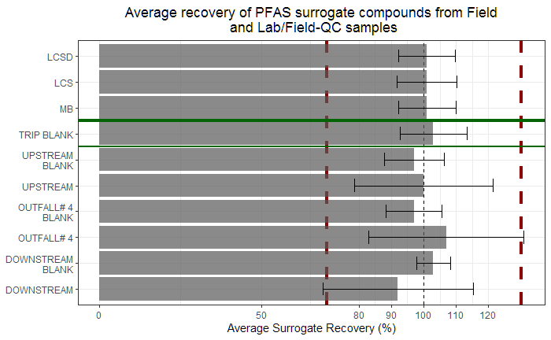

```r
data01 %>% filter(is.na(record_exclude) & grepl("^STL", .$CAS)) %>%
  select(Samp_grp, everything()) %>%
  group_by(Samp_ID) %>%
  summarize(Avg_SURR_recov = round(mean(Result.Value, na.rm=T)),
            sd = round(sd(Result.Value, na.rm=T), digits=1)) %>% ungroup() %>%
  ggplot(.) + theme_bw() + theme(plot.title=element_text(hjust=0.5)) +
  geom_hline(yintercept=100, lty=2, col="black") +
  geom_hline(yintercept=c(70, 130), lty=2, col="darkred", size=1.5) +
  geom_col(aes(x=Samp_ID, y=Avg_SURR_recov), alpha=0.7) +
  labs(x=NULL, y="Average Surrogate Recovery (%)") +
  geom_errorbar(aes(x=Samp_ID, ymax=(sd+Avg_SURR_recov), ymin=(Avg_SURR_recov-sd)),
                width=0.5) +
  scale_x_discrete(labels=scales::wrap_format(12),
                   limits=c("DOWNSTREAM", "DOWNSTREAM BLANK",
                            "OUTFALL# 4", "OUTFALL# 4 BLANK",
                            "UPSTREAM", "UPSTREAM BLANK","TRIP BLANK",
                            "MB", "LCS", "LCSD")) +
  scale_y_continuous(breaks=c(0, 50, 80, 90, 100, 110, 120)) +
  geom_vline(xintercept = c(6.5, 7.5), size=c(1, 1.5), col="darkgreen") +
  coord_flip() + ggtitle("Average recovery of PFAS surrogate compounds from Field\n and Lab/Field-QC samples")
```

> While mean surrogate recovery remains centered around 100% across all lab and field samples, some evidence of a matrix effect from these field samples may be found in the higher variance of surrogate-recovery compared to QC-blanks

### 2.4 Sample Blanks

- Examine hits from field-blanks
- By Site

```r
data01 %>% filter(is.na(record_exclude) & !grepl("^STL", .$CAS)) %>%
  filter(grepl("BLANK", .$Samp_grp)) %>%
  group_by(Samp_grp) %>%
  summarize(Obs = n(),
            Hits = sum(!is.na(Result.Value)),
            p_Hits = sprintf("%.f%%", (Hits / Obs)*100)) %>%
   htmlTable::htmlTable(., css.cell = rbind(rep("padding-left: 0.8em; padding-right: 0.8em;font-size: 0.75em;", times=ncol(.)+1), matrix("padding-left: 0.75em; padding-right: 0.75em; font-size: 0.75em;", ncol=ncol(.)+1, nrow=nrow(.))), align="rlccr", caption="Occurence of PFAS-analyte hits by Sample-Location from field-blanks (190911)")
```

| Occurence of PFAS-analyte hits by Sample-Location from field-blanks (190911) | Occurence of PFAS-analyte hits by Sample-Location from field-blanks (190911) Samp_grp | Occurence of PFAS-analyte hits by Sample-Location from field-blanks (190911) Obs | Occurence of PFAS-analyte hits by Sample-Location from field-blanks (190911) Hits | Occurence of PFAS-analyte hits by Sample-Location from field-blanks (190911) p_Hits |
| --- | --- | --- | --- | --- |
| 1 | DOWNSTREAM BLANK | 32 | 4 | 12% |
| 2 | OUTFALL# 4 BLANK | 32 | 1 | 3% |
| 3 | TRIP BLANK | 32 | 2 | 6% |
| 4 | UPSTREAM BLANK | 32 | 4 | 12% |

- By Analyte

```r
data01 %>% filter(is.na(record_exclude) & !grepl("^STL", .$CAS)) %>%
  filter(grepl("BLANK", .$Samp_grp)) %>%
  group_by(Component) %>%
  summarize(Obs = n(),
            Hits = sum(!is.na(Result.Value)),
            p_Hits = sprintf("%.f%%", (Hits / Obs)*100)) %>%
  filter(Hits > 0) %>%
  arrange(desc(Hits)) %>%
   htmlTable::htmlTable(., css.cell = rbind(rep("padding-left: 0.8em; padding-right: 0.8em;font-size: 0.75em;", times=ncol(.)+1), matrix("padding-left: 0.75em; padding-right: 0.75em; font-size: 0.75em;", ncol=ncol(.)+1, nrow=nrow(.))), align="rlccr", caption="Occurence of PFAS-analyte hits by Analyte from field-blanks (190911 samples)")
```

| Occurence of PFAS-analyte hits by Analyte from field-blanks (190911 samples) | Occurence of PFAS-analyte hits by Analyte from field-blanks (190911 samples) Component | Occurence of PFAS-analyte hits by Analyte from field-blanks (190911 samples) Obs | Occurence of PFAS-analyte hits by Analyte from field-blanks (190911 samples) Hits | Occurence of PFAS-analyte hits by Analyte from field-blanks (190911 samples) p_Hits |
| --- | --- | --- | --- | --- |
| 1 | Perfluorohexanesulfonic acid (PFHxS) | 4 | 3 | 75% |
| 2 | Perfluorooctanesulfonic acid (PFOS) | 4 | 3 | 75% |
| 3 | 6:2 FTS | 4 | 2 | 50% |
| 4 | Perfluorooctanesulfonamide (FOSA) | 4 | 2 | 50% |
| 5 | Perfluorotetradecanoic acid (PFTeA) | 4 | 1 | 25% |

- Of the 4 field-blank samples, two analytes were detected in 3 of 4 sites, two analytes detected in 2 of 4 sites, and 1 analyte detected in 1 site
  - In a general sense, more frequent blank-detections were found for smaller C-chain (lower molecular weight) analytes
- Site x Analyte

```r
data01 %>% filter(is.na(record_exclude) & !grepl("^STL", .$CAS)) %>%
  filter(grepl("BLANK", .$Samp_grp)) %>%
  filter(!is.na(Result.Value)) %>%
  {addmargins(table(.$Component, .$Samp_grp, useNA="ifany", deparse.level = 2))} %>%
  htmlTable::htmlTable(., css.cell = rbind(rep("padding-left: 0.8em; padding-right: 0.8em;font-size: 0.75em;", times=ncol(.)+1), matrix("padding-left: 0.75em; padding-right: 0.75em; font-size: 0.75em;", ncol=ncol(.)+1, nrow=nrow(.))), align="l|cccc|c", caption="Occurence of PFAS-analyte hits by Analyte and Site from field-blanks (190911 samples)")
```

| Occurence of PFAS-analyte hits by Analyte and Site from field-blanks (190911 samples) | Occurence of PFAS-analyte hits by Analyte and Site from field-blanks (190911 samples) .$Samp_grp DOWNSTREAM BLANK | Occurence of PFAS-analyte hits by Analyte and Site from field-blanks (190911 samples) .$Samp_grp OUTFALL# 4 BLANK | Occurence of PFAS-analyte hits by Analyte and Site from field-blanks (190911 samples) .$Samp_grp TRIP BLANK | Occurence of PFAS-analyte hits by Analyte and Site from field-blanks (190911 samples) .$Samp_grp UPSTREAM BLANK | Occurence of PFAS-analyte hits by Analyte and Site from field-blanks (190911 samples) | Occurence of PFAS-analyte hits by Analyte and Site from field-blanks (190911 samples) Sum |
| --- | --- | --- | --- | --- | --- | --- |
| .$Component |  |  |  |  |  |  |
| 6:2 FTS | 1 | 0 | 0 | 1 |  | 2 |
| Perfluorohexanesulfonic acid (PFHxS) | 1 | 0 | 1 | 1 |  | 3 |
| Perfluorooctanesulfonamide (FOSA) | 1 | 0 | 0 | 1 |  | 2 |
| Perfluorooctanesulfonic acid (PFOS) | 0 | 1 | 1 | 1 |  | 3 |
| Perfluorotetradecanoic acid (PFTeA) | 1 | 0 | 0 | 0 |  | 1 |
| Sum | 4 | 1 | 2 | 4 |  | 11 |

> Also notable, 7 of the 11 field-blank *Hits* also were associated with evidence of positive-bias from laboratory method blanks (i.e. “B” flag)

#### **Magnitude of Field-Blank hits**

> Result.Value(Method-Blank(PFAS)) / MDL(Method-Blank(PFAS)) = magnitude of blank above detection (i.e. MDL)

```r
data01 %>% filter(is.na(record_exclude) & !grepl("^STL", .$CAS)) %>%
  filter(grepl("BLANK", .$Samp_grp)) %>%
  filter(!is.na(Result.Value)) %>%
  group_by(Samp_ID, Component) %>%
  summarise(Obs = n(),
            magn_blank_mdl = sprintf("%.2f", (Result.Value / MDL)),
            magn_blank_rl = sprintf("%.2f", Result.Value / RL),
            B_Flag = sum(grepl("B", Footnotes), na.rm=T),
            RVal_est = sum(grepl("J", Footnotes), na.rm=T)) %>% ungroup() %>%
  arrange(match(Samp_ID, c("UPSTREAM","UPSTREAM BLANK","OUTFALL# 4","OUTFALL# 4 BLANK",
                           "DOWNSTREAM","DOWNSTREAM BLANK",
                           "TRIP BLANK","LCS","LCSD","MB"))) %>%
  htmlTable::htmlTable(., css.cell = rbind(rep("padding-left: 0.8em; padding-right: 0.8em;font-size: 0.75em;", times=ncol(.)+1), matrix("padding-left: 0.75em; padding-right: 0.75em; font-size: 0.75em;", ncol=ncol(.)+1, nrow=nrow(.))), align="rll|c|cc|cc", caption="Magnitude of field-blank hits, by sample and analyte", header=c("Sample name", "Analyte", "Obs", "Blank vs MDL", "Blank vs RL", "Blank Flag?", "J-Flag?"), n.tspanner=c(4,1,4,2), tspanner=rep("", 4))
```

| Magnitude of field-blank hits, by sample and analyte | Magnitude of field-blank hits, by sample and analyte Sample name | Magnitude of field-blank hits, by sample and analyte Analyte | Magnitude of field-blank hits, by sample and analyte Obs | Magnitude of field-blank hits, by sample and analyte Blank vs MDL | Magnitude of field-blank hits, by sample and analyte Blank vs RL | Magnitude of field-blank hits, by sample and analyte Blank Flag? | Magnitude of field-blank hits, by sample and analyte J-Flag? |
| --- | --- | --- | --- | --- | --- | --- | --- |
| 1 | UPSTREAM BLANK | 6:2 FTS | 1 | 1.10 | 0.11 | 0 | 1 |
| 2 | UPSTREAM BLANK | Perfluorohexanesulfonic acid (PFHxS) | 1 | 1.71 | 0.14 | 1 | 1 |
| 3 | UPSTREAM BLANK | Perfluorooctanesulfonamide (FOSA) | 1 | 1.03 | 0.18 | 1 | 1 |
| 4 | UPSTREAM BLANK | Perfluorooctanesulfonic acid (PFOS) | 1 | 2.22 | 0.60 | 0 | 1 |
| 5 | OUTFALL# 4 BLANK | Perfluorooctanesulfonic acid (PFOS) | 1 | 9.39 | 2.56 | 0 | 0 |
| 6 | DOWNSTREAM BLANK | 6:2 FTS | 1 | 2.89 | 0.29 | 0 | 1 |
| 7 | DOWNSTREAM BLANK | Perfluorohexanesulfonic acid (PFHxS) | 1 | 1.80 | 0.15 | 1 | 1 |
| 8 | DOWNSTREAM BLANK | Perfluorooctanesulfonamide (FOSA) | 1 | 1.39 | 0.24 | 1 | 1 |
| 9 | DOWNSTREAM BLANK | Perfluorotetradecanoic acid (PFTeA) | 1 | 1.00 | 0.14 | 1 | 1 |
| 10 | TRIP BLANK | Perfluorohexanesulfonic acid (PFHxS) | 1 | 1.50 | 0.13 | 1 | 1 |
| 11 | TRIP BLANK | Perfluorooctanesulfonic acid (PFOS) | 1 | 2.40 | 0.67 | 1 | 1 |

- Potentially the most significant blank-contaminant was observed from the `OUTFALL# 4 BLANK` for **PFOS**, which had no B-flag, and the **result was 2.6 times the `Reporting limit`**
  - This blank hit may be indicative of the high ambient environmental concentrations of PFOS during the storm event and AFF-contaminant release

### Add Synonyms for Components

- Need to add acronyms for all analytes

```r
data01 %<>% mutate(Nym=sub(".*\\( *(.*?) *\\).*", "\\1", Component)) %>%
  select(record_exclude:Component, Nym, everything())
```

#### **FIG**: Field-blank PFAS hits

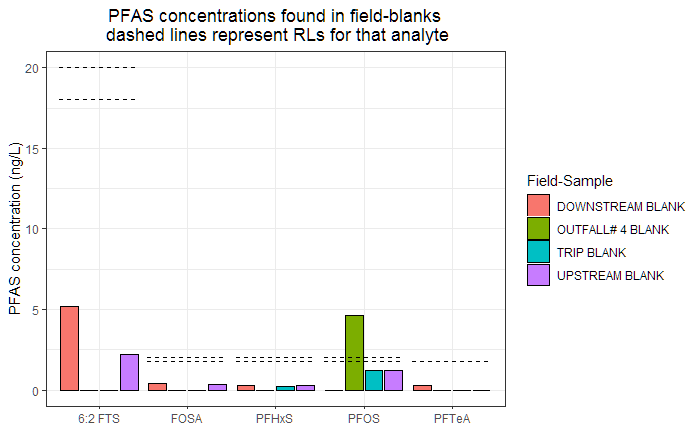

```r
data01 %>% filter(is.na(record_exclude) & !grepl("^STL", .$CAS)) %>%
  filter(grepl("BLANK", .$Samp_grp)) %>%
  filter(!is.na(Result.Value)) %>%
  select(Samp_grp, Component, Nym, Result.Value, Result_flag, Footnotes, VALUE,
         Units, RL, MDL) %>%
  complete(Samp_grp, Nym, fill = list(Result.Value=0)) %>%
  ggplot(.) + theme_bw() + theme(plot.title=element_text(hjust=0.5)) +
  geom_col(aes(x=factor(Nym), y=Result.Value, fill=Samp_grp),
           position=position_dodge2(preserve="single"), col="black") +
  geom_errorbar(aes(x=factor(Nym), ymin=RL, ymax=RL, group=Samp_grp),
                col="black", na.rm=T, lty=2) +
  ggtitle("PFAS concentrations found in field-blanks\n dashed lines represent RLs for that analyte") +
  labs(x=NULL, y="PFAS concentration (ng/L)", fill="Field-Sample")
```

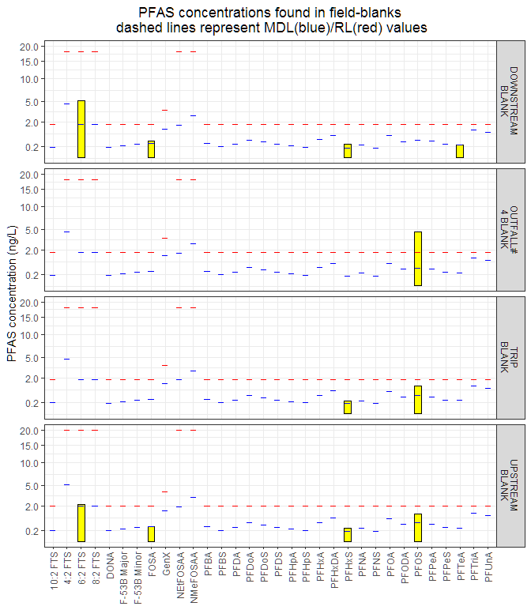

```r
# fig.height=8, fig.width=7
# fig.asp=1.15
data01 %>% filter(is.na(record_exclude) & !grepl("^STL", .$CAS)) %>%
  filter(grepl("BLANK", .$Samp_grp)) %>%
  select(Samp_grp, Component, Nym, Result, Result.Value, Result_flag, Footnotes, VALUE,
         Units, RL, MDL) %>%
  ggplot(.) + theme_bw() +
  theme(plot.title=element_text(hjust=0.5),
        axis.text.x=element_text(angle=90, hjust=1, vjust=0.5)) +
  facet_grid(Samp_grp ~ .,
             labeller=labeller(Samp_grp = label_wrap_gen(10))) +
  geom_col(aes(x=factor(Nym), y=Result.Value),
           position=position_dodge2(preserve="single", width=0.9), col="black",
           width=0.5, na.rm=T, fill="yellow") +
  labs(x=NULL, y="PFAS concentration (ng/L)", fill="Field-Sample") +
  geom_segment(aes(x=as.numeric(factor(Nym))-0.2, y=RL,
                   xend=as.numeric(factor(Nym))+0.2, yend=RL), na.rm=T,
               col="red") +
  geom_segment(aes(x=as.numeric(factor(Nym))-0.2, y=MDL,
                   xend=as.numeric(factor(Nym))+0.2, yend=MDL), na.rm=T,
               col="blue") +
  scale_y_continuous(trans="sqrt", limits=c(0, NA),
                     breaks=c(0.2,2, 5, 10, 15, 20, 25)) +
  ggtitle("PFAS concentrations found in field-blanks\n dashed lines represent MDL(blue)/RL(red) values")
```

### 2.5 Review Site Results

#### **FIG**: Site Results

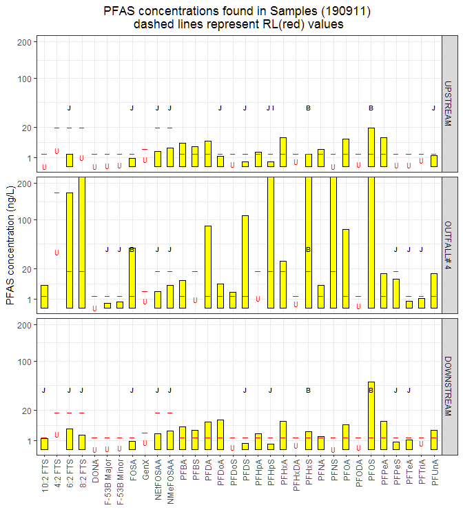

```r
#
data01 %>% filter(is.na(record_exclude) & !grepl("^STL", .$CAS) & SampleNumber != "QC") %>%
  filter(!grepl("BLANK", .$Samp_grp)) %>%
  select(Samp_grp, Component, Nym, Result.Value, Result_flag, Footnotes, VALUE,
         Units, RL, MDL) %>%
  mutate(Samp_grp = factor(Samp_grp, levels=c("UPSTREAM", "OUTFALL# 4", "DOWNSTREAM"))) %>%
  ggplot(.) + theme_bw() +
  theme(plot.title=element_text(hjust=0.5),
        axis.text.x = element_text(angle=90, hjust=1, vjust=0.5)) +
  facet_grid(Samp_grp ~ .,
             labeller=labeller(Samp_grp = label_wrap_gen(12))) +
  geom_col(aes(x=factor(Nym), y=Result.Value), na.rm=T,
           position=position_dodge2(preserve="single"), col="black",
           width=0.5, fill="yellow") +
  geom_segment(aes(x=as.numeric(factor(Nym))-0.2, y=RL,
                   xend=as.numeric(factor(Nym))+0.2, yend=RL), na.rm=T,
               col="red") +
  geom_text(aes(x=factor(Nym), y=MDL, label=Result_flag), na.rm=T,
            size=3, vjust=1, hjust=0.4, check_overlap = T, col="red") +
  geom_text(aes(x=factor(Nym), y=50, label=Footnotes), na.rm=T, fontface="bold",
            size=2.5, vjust=1, hjust=0.4, check_overlap = T, col="black") +
  labs(x=NULL, y="PFAS concentration (ng/L)", fill="Field-Sample") +
  scale_y_continuous(name="PFAS concentration (ng/L)", oob=squish,
                     trans="sqrt",
                     breaks=c(0.01, 1, 20, 100, 200, 400, 1000),
                     limits=c(NA, NA)) +
  coord_cartesian(ylim=c(0.01, 200)) +
  ggtitle("PFAS concentrations found in Samples (190911) \ndashed lines represent RL(red) values")
```

### 2.6 Compare Site values

```r
data01 %>% filter(is.na(record_exclude) & !grepl("^STL", .$CAS) & SampleNumber != "QC") %>%
  group_by(Samp_grp) %>%
  summarize(Obs=n(),
            NonDetect=sum(!is.na(Result_flag), na.rm=T),
            B_flag=sum(grepl("B", Footnotes), na.rm=T),
            Total_PFAS=sprintf("%.1f", sum(Result.Value, na.rm=T))) %>%
  htmlTable::htmlTable(., css.cell = rbind(rep("padding-left: 0.8em; padding-right: 0.8em;font-size: 0.75em;", times=ncol(.)+1), matrix("padding-left: 0.75em; padding-right: 0.75em; font-size: 0.75em;", ncol=ncol(.)+1, nrow=nrow(.))), align="rl|c|cc|r", caption="Total quantified PFAS per field-sample (ng PFAS/L)")
```

| Total quantified PFAS per field-sample (ng PFAS/L) | Total quantified PFAS per field-sample (ng PFAS/L) Samp_grp | Total quantified PFAS per field-sample (ng PFAS/L) Obs | Total quantified PFAS per field-sample (ng PFAS/L) NonDetect | Total quantified PFAS per field-sample (ng PFAS/L) B_flag | Total quantified PFAS per field-sample (ng PFAS/L) Total_PFAS |
| --- | --- | --- | --- | --- | --- |
| 1 | DOWNSTREAM | 32 | 10 | 2 | 153.6 |
| 2 | DOWNSTREAM BLANK | 32 | 28 | 3 | 6.2 |
| 3 | OUTFALL# 4 | 32 | 7 | 2 | 325167.6 |
| 4 | OUTFALL# 4 BLANK | 32 | 31 | 0 | 4.6 |
| 5 | TRIP BLANK | 32 | 30 | 2 | 1.4 |
| 6 | UPSTREAM | 32 | 14 | 2 | 93.5 |
| 7 | UPSTREAM BLANK | 32 | 28 | 2 | 4.0 |

## END

```r
# CHL1016_09 %>% select(contains("status", ignore.case = T)) %>% names(.)
# CHL1016_05 %>% {addmargins(table(.$PROJ_grp, .$RECORD_STATUS,
#                                  useNA="ifany", deparse.level = 2))}
# CHL1016_07 %>% distinct(RECORD_STATUS) %$% RECORD_STATUS
```

```r
lastwork.date <- format(Sys.Date(), "%y%m%d")
```

**Start work date ::** 190930  
**Last work date ::** 191002  
**Current review date ::** 191002

eof